# Lab 7: Functions and Fish

Author

Jasmine Cabrera

## 1.0 The Data

This lab’s data set concerns mark-recapture data on fish from the Blackfoot River, outside of Helena, Montana.

Mark-recapture is a common method used by Ecologists to estimate an animal population’s size, when it is impossible to conduct a census (count every animal). This method works by “tagging” animals with a tracking device, so scientists can track their movement and / or presence.

```r
library(tidyverse)
library(here)
library(scales)

blackfoot <- read_csv(here("data", "BlackfootFish.csv"))
```

## 2.0 Part One: Summaries and Plots (Midterm Review)

### 2.1 Summarizing Missing Data

The measurements of each fish captured were taken by a Biologist on a raft. This lack of “laboratory setting” opens the door to the possibility of measurement errors.

- What variable(s) have missing values present?
- How many observations within each variable have missing values?

Output both pieces of information in one table!

```r
NAsum <- blackfoot |>
  mutate(across(.cols = trip : species,
                ~ sum(is.na(.x)))) |>
  pivot_longer("trip" : "species",
               names_to = "Variable Name",
               values_to = "Missing Values")
head(NAsum)
```

```
# A tibble: 6 × 2
  `Variable Name` `Missing Values`
  <chr>                      <int>
1 trip                           0
2 mark                           0
3 length                         0
4 weight                      1796
5 year                           0
6 section                        0
```

**Answer:** The only variable with missing values is the weight variable with 1,796 observations of missing values. All other variables in the data set have 0 observations of missing values.

### 2.2 Visualizing Missing Data

Unfortunately, these missing values are not for only one year, trip, or section of river.

Create a thoughtful visualization exploring the frequency of missing values across the different years, sections, and trips.

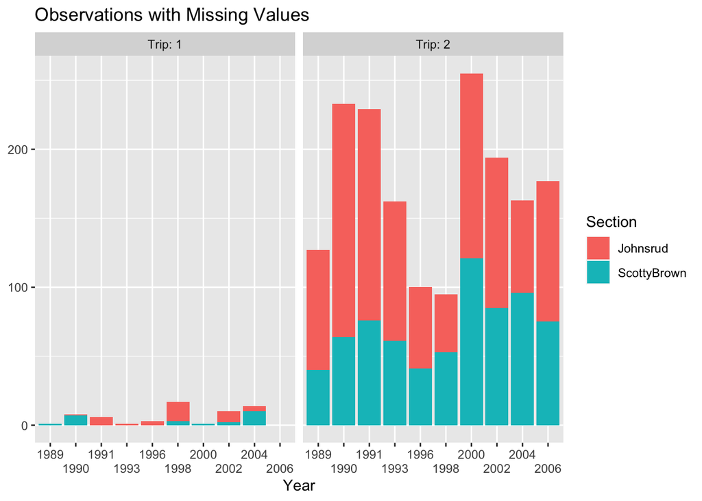

```r
visualizing <- blackfoot |>
  filter(if_any(.cols = trip : species,
                ~ is.na(.x))) |>
  mutate(trip = as.factor(trip),
         year = as.factor(year)) |>
  rename("Trip" = trip)

ggplot(data = visualizing,
       mapping = aes(x = year,
                     fill = section)) +
  geom_bar() +
  facet_wrap(~ Trip,
             labeller = labeller(Trip = label_both)) +
        labs(x = "Year",
             y = NULL,
             title = "Observations with Missing Values",
             fill = "Section") +
  scale_x_discrete(guide = guide_axis(n.dodge = 2))
```

**Sources:**

tidyverse.org/blog/2021/02/dplyr-1-0-4-if-any/

https://www.tidyverse.org/blog/2021/02/dplyr-1-0-4-if-any/

https://ggplot2.tidyverse.org/reference/labeller.html

## 3.0 Part Two: Adjusting the Data (Function Writing)

The following `R` code would carry out this rescaling procedure for the `length` and `weight` columns of the data:

```
BlackfootFish <- BlackfootFish |>
  mutate(length = (length - min(length, na.rm = TRUE)) /
           (max(length, na.rm = TRUE) - min(length)),
         weight = (weight - min(weight, na.rm = TRUE)) /
           (max(weight, na.rm = TRUE) - min(length, na.rm = TRUE))
         )
```

This process of duplicating an action multiple times makes it difficult to understand the intent of the process. Additionally, it makes it very difficult to spot the mistakes. *Did you spot the mistake in the weight conversion?*

Often you will find yourself in the position of needing to find a function that performs a specific task, but you do not know of a function or a library that would help you. You could spend time Googling for a solution, but in the amount of time it takes you to find something you could have already written your own function!

### 3.1 Writing a Function

Let's transform the repeated process above into a `rescale_01()` function.

- The function should take a single vector as its input.
- The function should return the rescaled vector.

```r
rescale_01 <- function(vec){

  stopifnot(is.numeric(vec), length(vec) > 1)

  max = max(vec, na.rm = TRUE)
  min = min(vec, na.rm = TRUE)

  return ((vec - min) / (max - min))
}

test <- c(0, 1, 4, 3, 10)
test1 <- c(0, 1, 4, 9, 20, 100)

rescale_01(test)
```

```
[1] 0.0 0.1 0.4 0.3 1.0
```

```r
rescale_01(test1)
```

```
[1] 0.00 0.01 0.04 0.09 0.20 1.00
```

### 3.2 Adding Stops

Now, let's incorporate some checks into your function! Modify your previous code to create the following checks:

- the function should stop if the input vector is not numeric
- the function should stop if the length of the vector is not greater than 1

**No need to write code here, simply add these stops to your code from Task 1!**

### 3.3 Performing a Simple Test

First, test your function on the simple vector below. **Add code** that verifies the maximum of your rescaled vector is 1 and the minimum is 0!

```r
x <- c(1:85, NA)

rescale_01(x)
```

```
 [1] 0.00000000 0.01190476 0.02380952 0.03571429 0.04761905 0.05952381
 [7] 0.07142857 0.08333333 0.09523810 0.10714286 0.11904762 0.13095238
[13] 0.14285714 0.15476190 0.16666667 0.17857143 0.19047619 0.20238095
[19] 0.21428571 0.22619048 0.23809524 0.25000000 0.26190476 0.27380952
[25] 0.28571429 0.29761905 0.30952381 0.32142857 0.33333333 0.34523810
[31] 0.35714286 0.36904762 0.38095238 0.39285714 0.40476190 0.41666667
[37] 0.42857143 0.44047619 0.45238095 0.46428571 0.47619048 0.48809524
[43] 0.50000000 0.51190476 0.52380952 0.53571429 0.54761905 0.55952381
[49] 0.57142857 0.58333333 0.59523810 0.60714286 0.61904762 0.63095238
[55] 0.64285714 0.65476190 0.66666667 0.67857143 0.69047619 0.70238095
[61] 0.71428571 0.72619048 0.73809524 0.75000000 0.76190476 0.77380952
[67] 0.78571429 0.79761905 0.80952381 0.82142857 0.83333333 0.84523810
[73] 0.85714286 0.86904762 0.88095238 0.89285714 0.90476190 0.91666667
[79] 0.92857143 0.94047619 0.95238095 0.96428571 0.97619048 0.98809524
[85] 1.00000000         NA
```

### 3.4 Performing a More Difficult Test

Next, let's test the function on the `length` column of the `BlackfootFish` data set.

Make plots of the original values of `length` and the rescaled values of `length`. Output your plots **stacked vertically**, so the reader can confirm the only aspect that has changed is the scale.

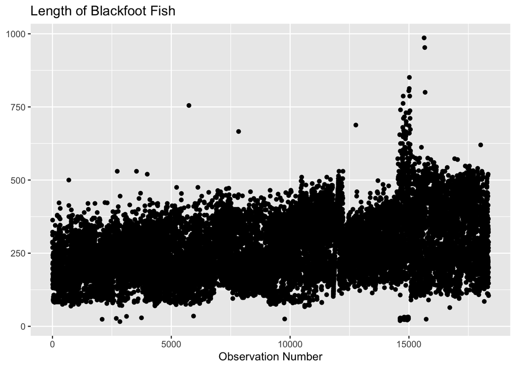

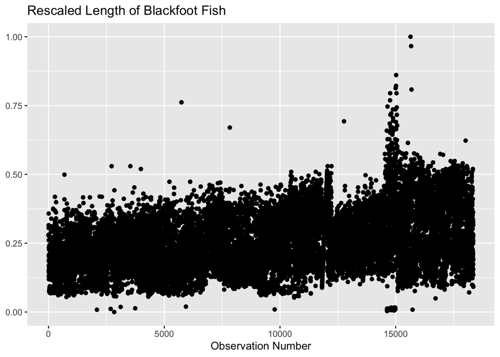

```r
ggplot(data = blackfoot,
       mapping = aes(x = 1:nrow(blackfoot),
                     y = length)) +
  geom_point() +
  labs(x = "Observation Number",
       y = NULL,
       title = "Length of Blackfoot Fish")
ggplot(data = blackfoot,
       mapping = aes(x = 1:nrow(blackfoot),
                     y = rescale_01(length))) +
  geom_point() +
  labs(x = "Observation Number",
       y = NULL,
       title = "Rescaled Length of Blackfoot Fish")
```

**Sources:**

https://statisticsglobe.com/plot-only-one-variable-in-ggplot2-plot-r

### 3.5 Incorporating Variables

Suppose you would like to make a more general `rescale_column()` function that perform operations on any variable within a data set. Ideally, your function would take a dataframe and a variable name as inputs and return a dataframe where the variable has been rescaled.

Create a `rescale_column()` that accepts two arguments:

1. a data frame
2. the name(s) of the variable(s) to be rescaled

The body of the function should call the original `rescale_01()` function you wrote previously.

```r
rescale_column <- function(dataframe, variables){
  stopifnot(is.data.frame(dataframe))

  dataframe <- dataframe |>
    mutate(across(.cols = {{variables}},
                  ~ rescale_01(.x)))

  return(dataframe)
}
```

### 3.6 Another Function Test

Alright, now let's put your `rescale_column()` function to work! Use your `rescale_column()` function to rescale **both** the `length` and `weight` columns.

I expect that you carry out this process by calling the `rescale()` function *one* time!

I advise against using functions like `mutate_at()`, which have been superseded.

```r
rescale_col_test <- blackfoot |>
  rescale_column(length:weight) |>
  mutate(id = seq_along(1:nrow(blackfoot))) |>
  select(id, length:weight)


rescale_confirm <- blackfoot |>
  mutate(across(.cols = length:weight,
                ~ rescale(.x,
                          to = c(0,1),
                          from = range(.x,
                                       na.rm = TRUE,
                                       finite = TRUE)))) |>
  mutate(id = seq_along(1:nrow(blackfoot))) |>
  select(id, length:weight) |>
  rename("rescale(length)" = "length",
         "rescale(weight)" = "weight")


rescale_compare <- full_join(rescale_col_test, rescale_confirm, by = "id")
rescale_compare <- rescale_compare |>
  select("weight", "rescale(weight)", "length", "rescale(length)")
rescale_compare
```

```
# A tibble: 18,352 × 4
    weight `rescale(weight)` length `rescale(length)`
     <dbl>             <dbl>  <dbl>             <dbl>
 1 0.0374            0.0374   0.280             0.280
 2 0.0406            0.0406   0.280             0.280
 3 0.0524            0.0524   0.277             0.277
 4 0.0588            0.0588   0.315             0.315
 5 0.0641            0.0641   0.305             0.305
 6 0.0812            0.0812   0.358             0.358
 7 0.0363            0.0363   0.261             0.261
 8 0.00855           0.00855  0.148             0.148
 9 0.0171            0.0171   0.203             0.203
10 0.00748           0.00748  0.145             0.145
# … with 18,342 more rows
```

**Answer:** The weight and length columns are the Blackfoot fish columns adjusted using my function rescale_column(), whereas, the rescale_weight() and rescale_length() columns are the Blackfoot fish columns adjusted using the rescale() function. We know the rescale_column works correctly because looking at the corresponding columns side by side, they are equivalent.